# HW2.Q4.Ko

## 4

```r
?swiss
head(swiss,5)
```

```
##              Fertility Agriculture Examination Education Catholic
## Courtelary        80.2        17.0          15        12     9.96
## Delemont          83.1        45.1           6         9    84.84
## Franches-Mnt      92.5        39.7           5         5    93.40
## Moutier           85.8        36.5          12         7    33.77
## Neuveville        76.9        43.5          17        15     5.16
##              Infant.Mortality
## Courtelary               22.2
## Delemont                 22.2
## Franches-Mnt             20.2
## Moutier                  20.3
## Neuveville               20.6
```

**(a)** (i) Examination and Education are seem to be linearly related to the fertility measure.

2. (Agriculture ~ Examination), (Agriculture ~ Education), (Examination ~ Education) are seem to be highly correlated.

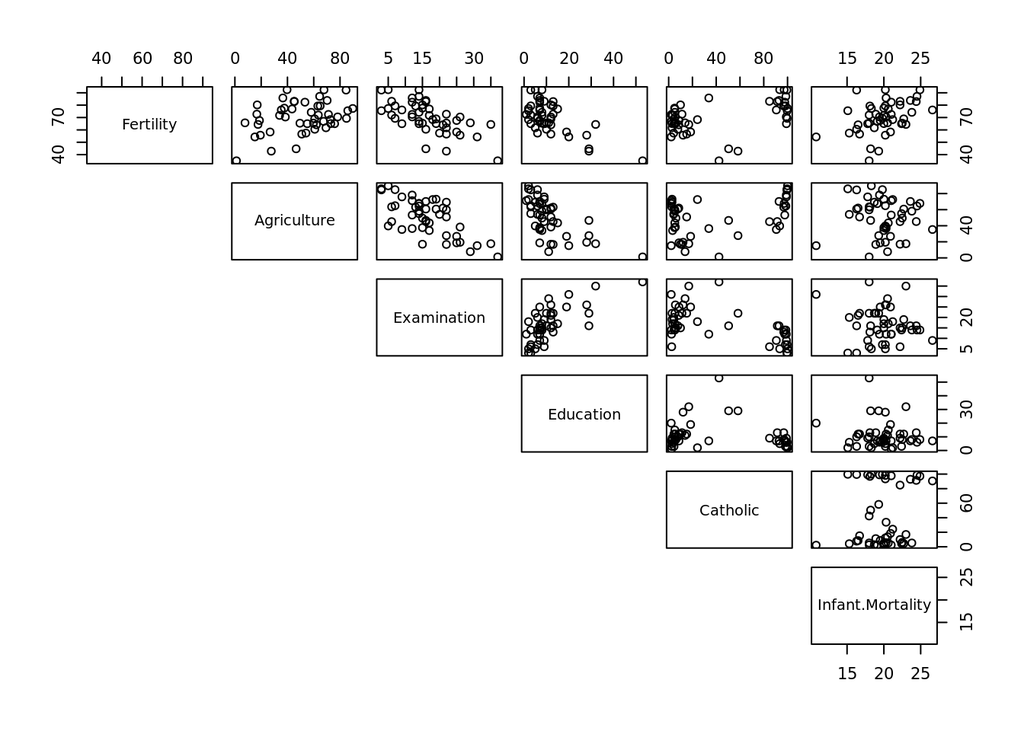

```r
pairs(swiss, lower.panel = NULL)
```

```r
cor(swiss)
```

```
##                   Fertility Agriculture Examination   Education   Catholic
## Fertility         1.0000000  0.35307918  -0.6458827 -0.66378886  0.4636847
## Agriculture       0.3530792  1.00000000  -0.6865422 -0.63952252  0.4010951
## Examination      -0.6458827 -0.68654221   1.0000000  0.69841530 -0.5727418
## Education        -0.6637889 -0.63952252   0.6984153  1.00000000 -0.1538589
## Catholic          0.4636847  0.40109505  -0.5727418 -0.15385892  1.0000000
## Infant.Mortality  0.4165560 -0.06085861  -0.1140216 -0.09932185  0.1754959
##                  Infant.Mortality
## Fertility              0.41655603
## Agriculture           -0.06085861
## Examination           -0.11402160
## Education             -0.09932185
## Catholic               0.17549591
## Infant.Mortality       1.00000000
```

**(b)**

$H_0: \beta_{agriculture} = \beta_{examination} = \beta_{education} = \beta_{catholic} = \beta_{infant.mortlaity} = 0$ $H_a$: at least one of the $\beta_j \neq 0$ for j = $1, ... ,5$

- F-statistic: 19.8
- p-value: 0.000000000559

With small p-value, we can reject the null hypothesis and claim that our model is useful.

2. In terms of Examination, the negative linear relationship can also be found in the form of the slope -0.2580. In terms of Education, the negative linear relationship can also be found in the form of the slope -0.8709. Both results are in line with answer from previous question.

```r
result <- lm(Fertility ~ ., data = swiss)
summary(result)
```

```
##
## Call:
## lm(formula = Fertility ~ ., data = swiss)
##
## Residuals:
##      Min       1Q   Median       3Q      Max
## -15.2743  -5.2617   0.5032   4.1198  15.3213
##
## Coefficients:
##                  Estimate Std. Error t value Pr(>|t|)
## (Intercept)      66.91518   10.70604   6.250 1.91e-07 ***
## Agriculture      -0.17211    0.07030  -2.448  0.01873 *
## Examination      -0.25801    0.25388  -1.016  0.31546
## Education        -0.87094    0.18303  -4.758 2.43e-05 ***
## Catholic          0.10412    0.03526   2.953  0.00519 **
## Infant.Mortality  1.07705    0.38172   2.822  0.00734 **
## ---
## Signif. codes:  0 '***' 0.001 '**' 0.01 '*' 0.05 '.' 0.1 ' ' 1
##
## Residual standard error: 7.165 on 41 degrees of freedom
## Multiple R-squared:  0.7067, Adjusted R-squared:  0.671
## F-statistic: 19.76 on 5 and 41 DF,  p-value: 5.594e-10
```

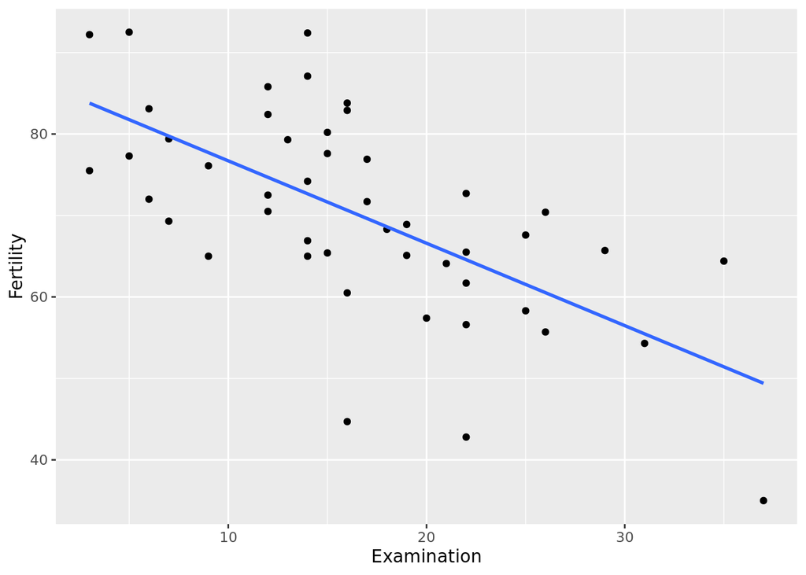

```r
ggplot(swiss, aes(x=Examination, y = Fertility)) +
  geom_point() +
  geom_smooth(method = "lm", se = FALSE)
```

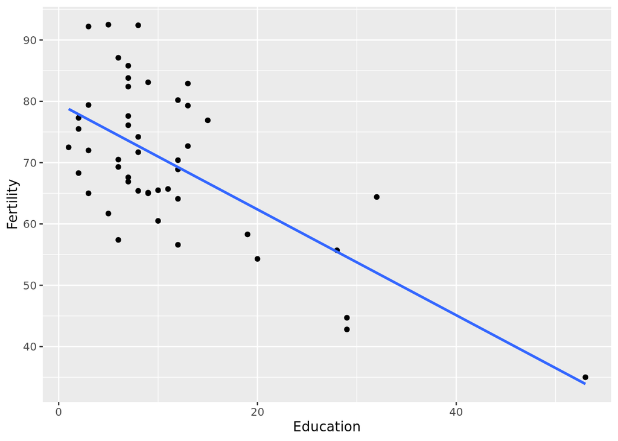

```r
ggplot(swiss, aes(x=Education, y = Fertility)) +
  geom_point() +
  geom_smooth(method = "lm", se = FALSE)
```

- F-statistic: 3.09
- p-value: 0.056

```r
reduced <- lm(Fertility ~ Education + Catholic + Infant.Mortality, data = swiss)
anova(reduced, result)
```

```
## Analysis of Variance Table
##
## Model 1: Fertility ~ Education + Catholic + Infant.Mortality
## Model 2: Fertility ~ Agriculture + Examination + Education + Catholic +
##     Infant.Mortality
##   Res.Df    RSS Df Sum of Sq      F  Pr(>F)
## 1     43 2422.2
## 2     41 2105.0  2     317.2 3.0891 0.05628 .
## ---
## Signif. codes:  0 '***' 0.001 '**' 0.01 '*' 0.05 '.' 0.1 ' ' 1
```

```r
nominator <- (2422 - 2105) / 2
denominator <- 2105 / 41
f_statistic <- nominator / denominator
f_statistic
```

```
## [1] 3.087173
```